# Assignment 3.1 Plots in R Base

First Creating the histogram and locating the median with a line

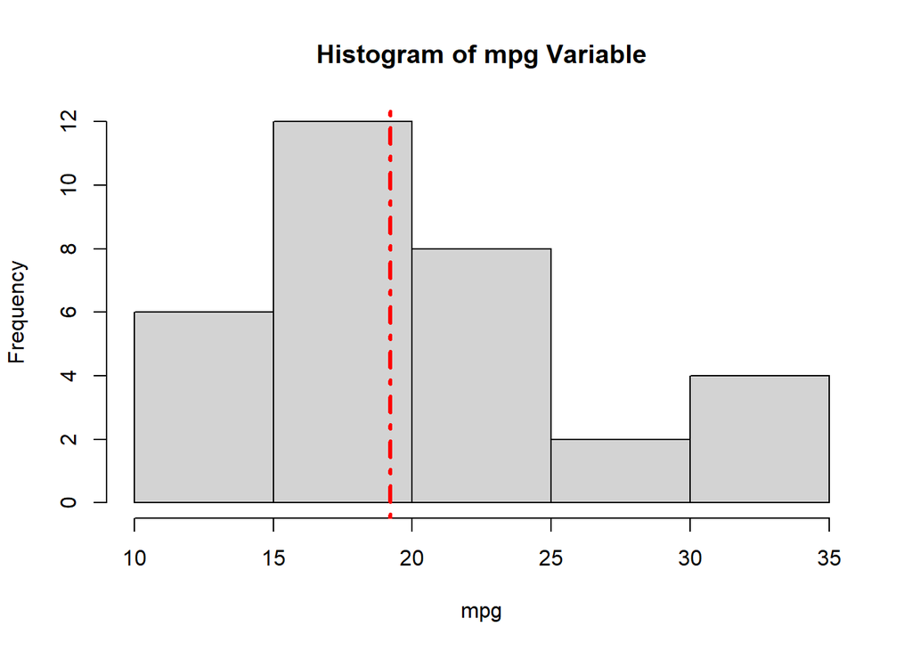

```r
hist(df$mpg , main = "Histogram of mpg Variable", xlab = "mpg", ylab = "Frequency")
abline(v = median(df$mpg), lwd = 3, lty = 4, col = "red")  #redline drawn from the median point
```

We can also locate the median graphically for that we need to calculate the more than Cumulative sum and Less Than of Mpg variable and by plotting them in the same plot we get the intersection and that intersection will represent the median value

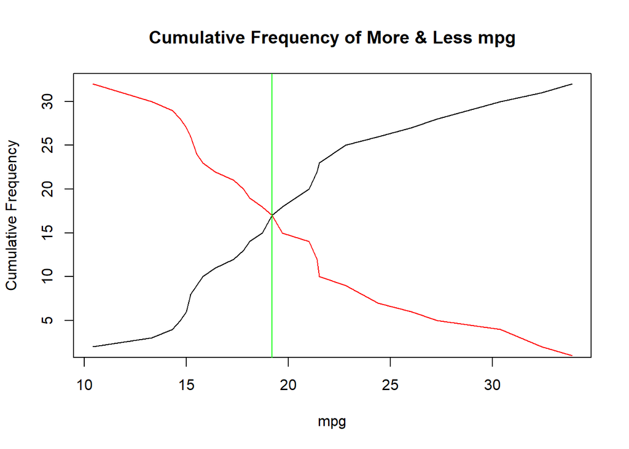

```r
#this can be done graphically as well
mpg_sorted <- sort(df$mpg)

# Calculate the cumulative sum of frequencies for the "mpg" data
freq_more_than <- cumsum(table(mpg_sorted))
freq_less_than <- rev(cumsum(rev(table(mpg_sorted))))

# Plot the cumulative frequency curves
plot(names(freq_more_than), freq_more_than, type = "l", xlab = "mpg", ylab = "Cumulative Frequency", main = "Cumulative Frequency of More & Less mpg")
lines(names(freq_less_than), freq_less_than, type = "l", col = "red")

#Locate the point of intersection and draw the perpendicular line to the x-axis
intersection_index <- which.min(abs(freq_more_than - freq_less_than))
median_mpg <- names(freq_more_than)[intersection_index]
abline(v=median_mpg, col="green")
```

Here we locate the intersection point and plot in graph.

Now comparing the median values obtained from graphs and built in function and they are same

```r
# Compare the obtained median value with the result of the "median" function in R
median_value <- median(df$mpg)
cat("Graphical median:", median_mpg, "\n")
```

```
## Graphical median: 19.2
```

```r
cat("R median function:", median_value)
```

```
## R median function: 19.2
```

**#3. Locate mode of mpg variable of mtcars data graphically and compare the mode value with the in-built/custom function of R**

```r
mode(df$mpg)    #doesnot gives any result so need to calculate manually
```

```
## [1] "numeric"
```

So we calculate the mode by the formula 3*median - 2*mean

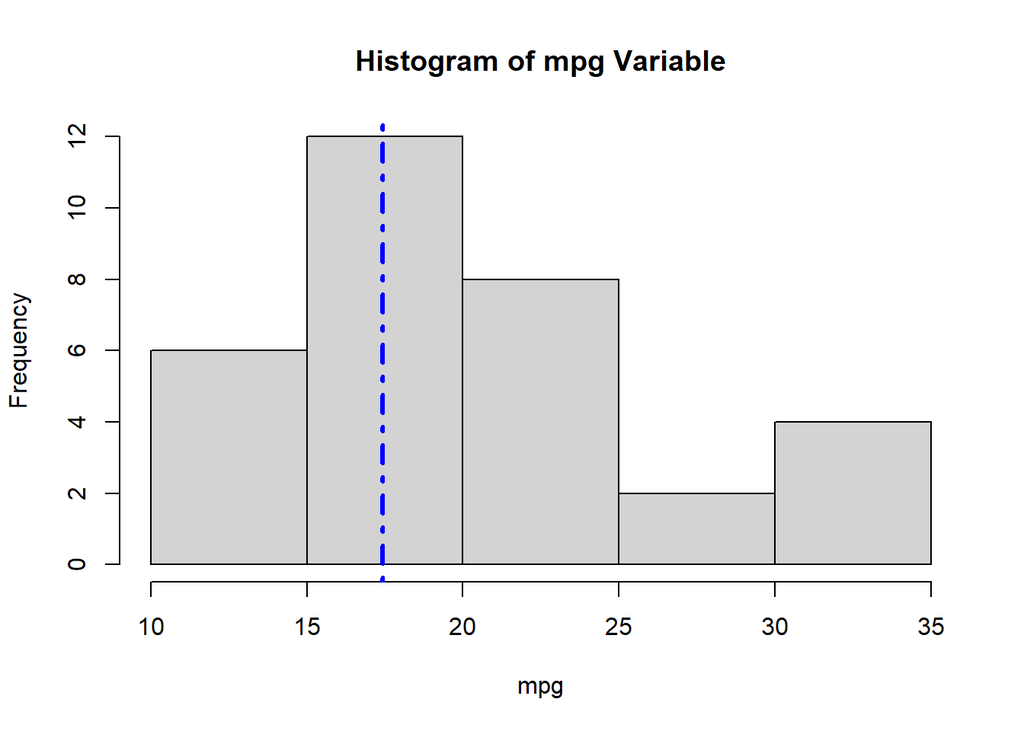

```r
#but we can get the mode by 3*median - 2*mean
mode_Value <- (3* median(df$mpg) - 2 * mean(df$mpg))   #17.42
hist(df$mpg , main = "Histogram of mpg Variable", xlab = "mpg", ylab = "Frequency")
abline(v = mode_Value, lwd = 3, lty = 4, col = "blue")
```

Now we create the histogram and plot the mode with a blue line

**#4. Create a scatterplot of mgp (dependent) and wt (independent) variable of mtcars data, add ablines at mean plus-minus 2 standard deviation and show the name of the cars with mpg > 2 standard deviation from mean inside the scatterplot obtained above**

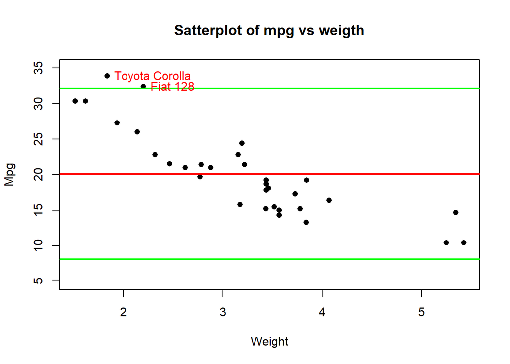

```r
plot(df$wt, df$mpg, pch =16, main = "Satterplot of mpg vs weigth", xlab = "Weight", ylab = "Mpg", ylim = c(5,35))
abline(h = mean(mtcars$mpg), col = "red", lwd = 2)

# calculate the upper and lower bounds for the ablines
mpg_upper <- (mean(df$mpg) + 2 * sd(df$mpg))
mpg_lower <- (mean(df$mpg) - 2 * sd(df$mpg))

#adding abline at mean +- 2 standard deviation
abline(h = mpg_upper, col = "green", lwd = 2)
abline(h = mpg_lower, col = "green", lwd = 2)

# label the points with mpg > 2 standard deviation from mean inside the scatterplot
text(df$wt[df$mpg > mpg_upper], df$mpg[df$mpg > mpg_upper], labels = rownames(df)[df$mpg > mpg_upper], pos = 4, col = "red")
```

Now adding the text label in the plot. we can also display the values like below

```r
#diaplay the name only
NameofCars <- rownames(df)[df$mpg > mpg_upper]
NameofCars
```

```
## [1] "Fiat 128"       "Toyota Corolla"
```

```r
#display the name of the cars with  milage lower than 15
Low_milage_Cars <- rownames(df)[df$mpg < 15]
Low_milage_Cars
```

```
## [1] "Duster 360"          "Cadillac Fleetwood"  "Lincoln Continental"
## [4] "Chrysler Imperial"   "Camaro Z28"
```

**#5. Create a x variable with 100 random numbers and y variable with x + 100 random numbers; create a factor variable with 100 monthly random observations, create a time series data with 100 random values starting from January 1970; create a date variable with 100 random values starting from 1970/01/01 increasing each day; create a new variable z with square of x variable**

```r
set.seed(26)
# Create x variable with 100 random numbers
x <- rnorm(100)

# Create y variable with x + 100 random numbers
y <- x + rnorm(100)

# Create factor variable with 100 monthly random observations
month <- sample(month.name, 100, replace = TRUE)
factor_var <- factor(month)

# Create time series data with 100 random values starting from January 1970
ts_data <- ts(rnorm(100), start = c(1970,1), frequency = 12)

# Create date variable with 100 random values starting from 1970/01/01 increasing each day
date_var <- seq(as.Date("1970/01/01"), by = "day", length = 100)

# Create new variable z with square of x variable
z <- function(x)x^2
```

**#6. Create a 2 x 3 plot window with scatterplot, barplot, boxplot, time series plot, date plot and square function plot**

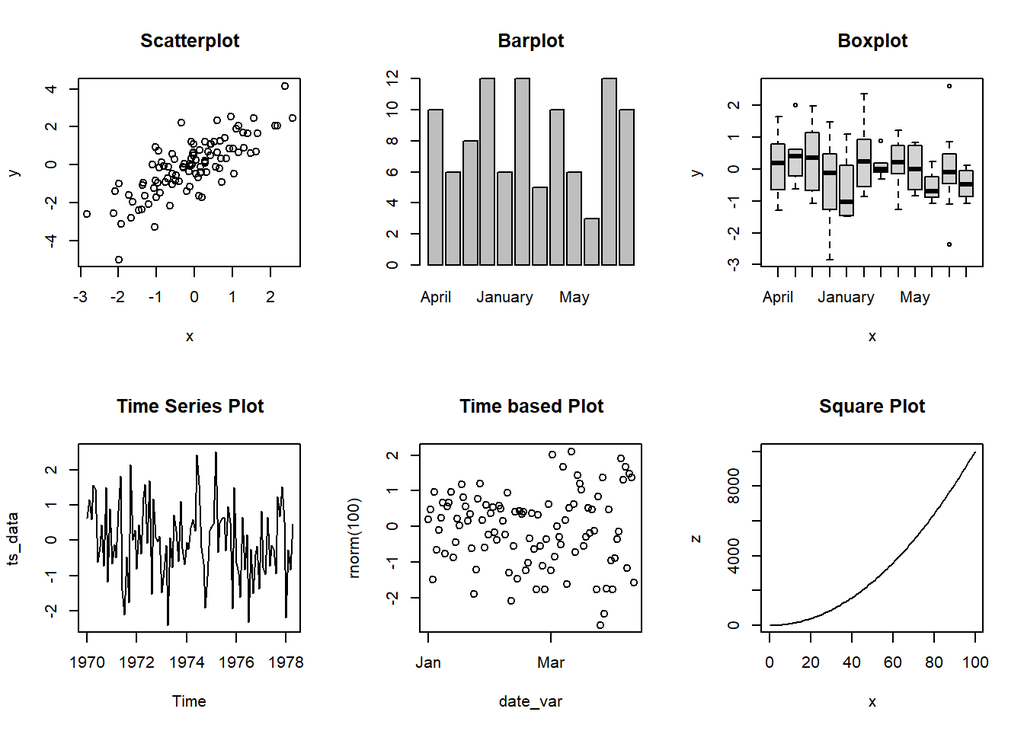

```r
par(mfrow = c(2,3))
plot(x,y, main = "Scatterplot")
plot(factor_var, main = "Barplot")
plot(factor_var, rnorm(100), main = "Boxplot")
plot(ts_data, main = "Time Series Plot")
plot(date_var, rnorm(100), main = "Time based Plot")
plot(z, 0,100, main = "Square Plot")
```

```r
# converting to 1 x 1 plot
par(mfrow = c(1,1))
```

**#7. Perform log transformation on x and z variables i.e. log of x, log of z and log of x and z in the plot command and interpret the results carefully**

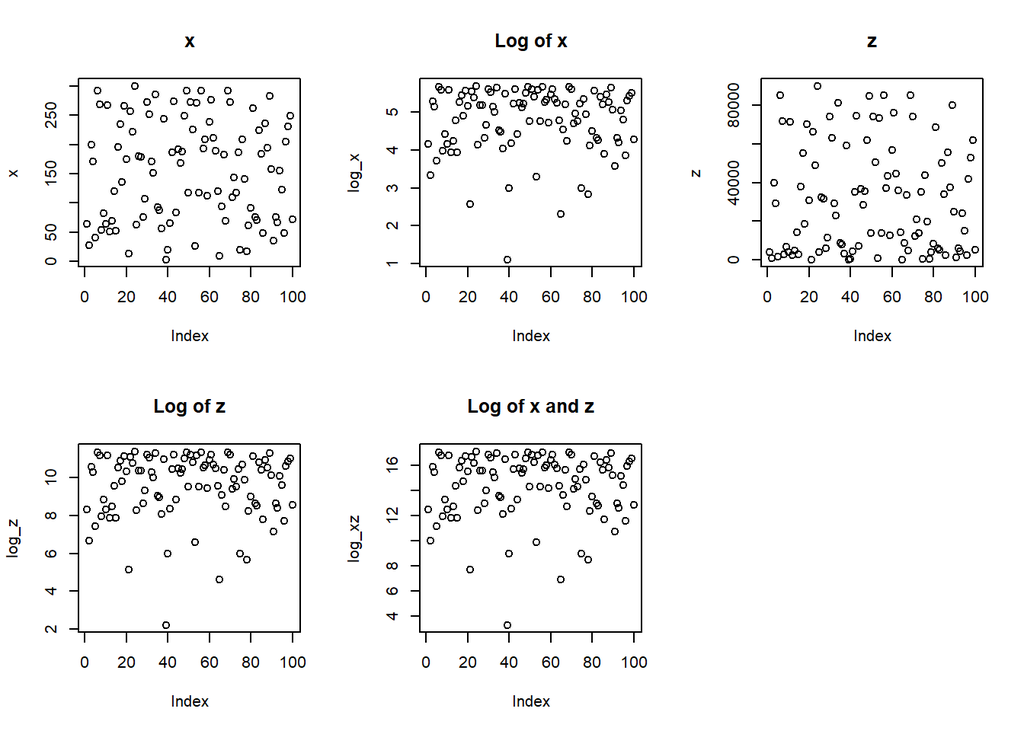

```r
# Log transformation of x and z variables
set.seed(26)
x <- sample(1:300, 100, replace = TRUE)
z <- x^2

log_x <- log(x)
log_z <- log(z)
log_xz <- log_x + log_z

# Plot the log transformed variables
par(mfrow = c(2, 3))
plot(x, main = "x")
plot(log_x, main = "Log of x")
plot(z, main = "z")
plot(log_z, main = "Log of z")
plot(log_xz, main = "Log of x and z")

# converting to 1 x 1 plot
par(mfrow = c(1,1))
```

**# 8. Create a 1x1 plot window with correlation matrix plot of first three numerical variable of mtcars data (cyl is not numeric, its factor!)**

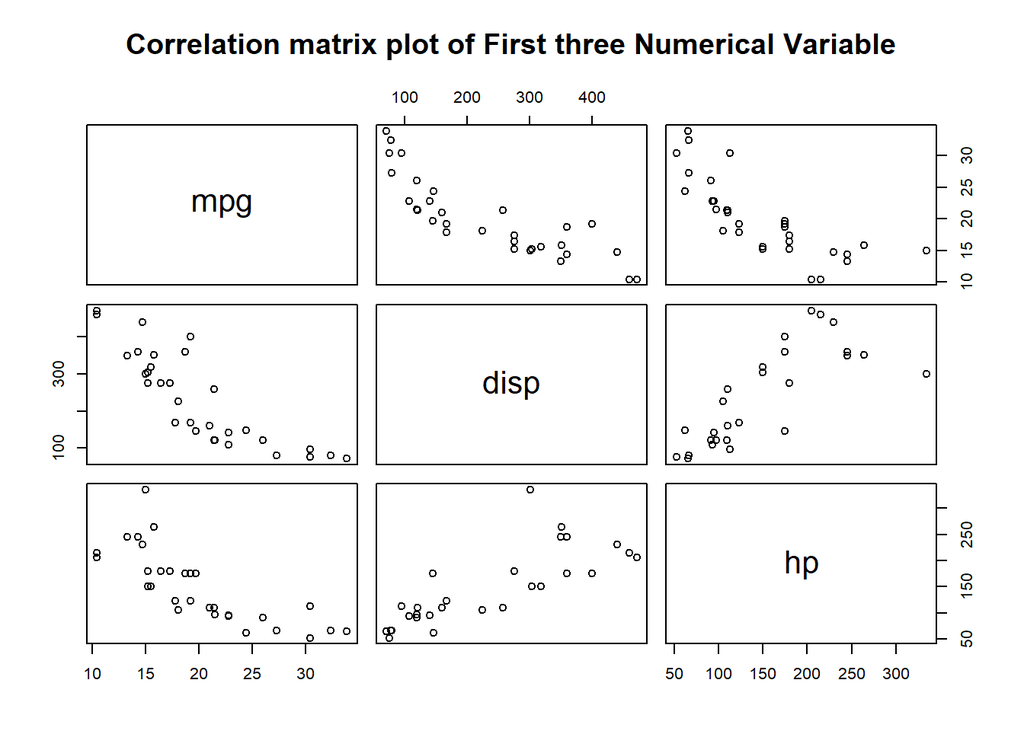

```r
plot(df[, c(1,3,4)], main = "Correlation matrix plot of First three Numerical Variable")
```

**# 9. Interpret the result of the correlation matrix plot obtained above with respect to the correlation coefficient to be used for each pair**

```r
cor(df[, c(1,3,4)])
```

```
##             mpg       disp         hp
## mpg   1.0000000 -0.8475514 -0.7761684
## disp -0.8475514  1.0000000  0.7909486
## hp   -0.7761684  0.7909486  1.0000000
```

From the above correlation coefficient we cay that : #mpg and disp negative correlation , #mpg to hp negative correlation ,#disp to hp positive correlation as 1 will give the positive correlation and -1 gives the negative correlation

**# 10. Write advantage and limitations of plots created using R base packages based on these nine steps**

Advantages of plots created using R base packages:

- Familiarity: R base graphics are part of the R language itself, so they are available by default and don’t require any additional packages to be installed. Many people are familiar with the syntax and functionality of R base graphics, so they can be a good choice for quick and simple data visualizations.
- Flexibility: R base graphics are highly customizable and can be used to create a wide variety of plots, including scatterplots, line plots, bar plots, and histograms. You can control many aspects of the plot, such as the axes, labels, colors, and legends.
- Integration: R base graphics can be easily integrated with other R functions and packages, which can be useful for data analysis and reporting. For example, you can create a plot using R base graphics and then use the summary() function to generate descriptive statistics for the same data.

Limitations of plots created using R base packages:

- Limited interactivity: R base graphics do not support interactive features such as zooming, panning, and hover-over tooltips. This can make it difficult to explore complex datasets and identify patterns or outliers.
- Limited aesthetics: While R base graphics are highly customizable, they may not have the same aesthetic appeal as plots created using other packages or tools. For example, some users may find the default colors or fonts used in R base graphics to be unappealing or difficult to read.
- Steep learning curve: While R base graphics can be powerful and flexible, they can also be challenging to learn and use effectively. The syntax and terminology used in R base graphics can be unfamiliar to new users, and creating complex plots may require a significant amount of trial and error. This can be a barrier to entry for some users who are new to R or data visualization in general.